# AN588 Final Homework 3 (Fall 2023)

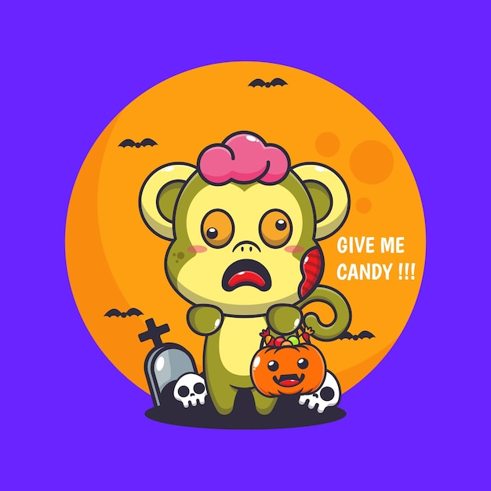

**The Most Adorable Undead Creature!!**

**Load Relevant Dataset**

```r
f <- curl("https://raw.githubusercontent.com/fuzzyatelin/fuzzyatelin.github.io/master/AN588_Fall23/zombies.csv")
```

## Question #1

**Calculate the population mean and standard deviation for each quantitative random variable (height, weight, age, number of zombies killed, and years of education). NOTE: You will not want to use the built in var() and sd() commands as these are for samples.**

```r
# Load the data from the CSV file
f <- read.csv(f)

# Create a population SD function
pop_sd <- function (data, mean) {
  sqrt(sum((data-mean)^2)/length(data))
}
# Generate the means and standard deviation for each variable
mean_height <- mean(f$height)
print(mean_height)
```

```
## [1] 67.6301
```

```r
(height_sd<-pop_sd(f$height, mean_height))
```

```
## [1] 4.30797
```

```r
mean_weight <- mean(f$weight)
print(mean_weight)
```

```
## [1] 143.9075
```

```r
(weight_sd<-pop_sd(f$weight, mean_weight))
```

```
## [1] 18.39186
```

```r
mean_age <- mean(f$age)
print(mean_age)
```

```
## [1] 20.04696
```

```r
(age_sd<-pop_sd(f$age, mean_age))
```

```
## [1] 2.963583
```

```r
mean_zombies_killed <- mean(f$zombies_killed)
print(mean_zombies_killed)
```

```
## [1] 2.992
```

```r
(zombies_killed_sd<-pop_sd(f$zombies_killed, mean_zombies_killed))
```

```
## [1] 1.747551
```

```r
mean_years_of_education <- mean(f$years_of_education)
print(mean_years_of_education)
```

```
## [1] 2.996
```

```r
(years_of_education_sd<-pop_sd(f$years_of_education, mean_years_of_education))
```

```
## [1] 1.675704
```

## Question #2

**Use {ggplot} to make boxplots of each of these variables by gender.**

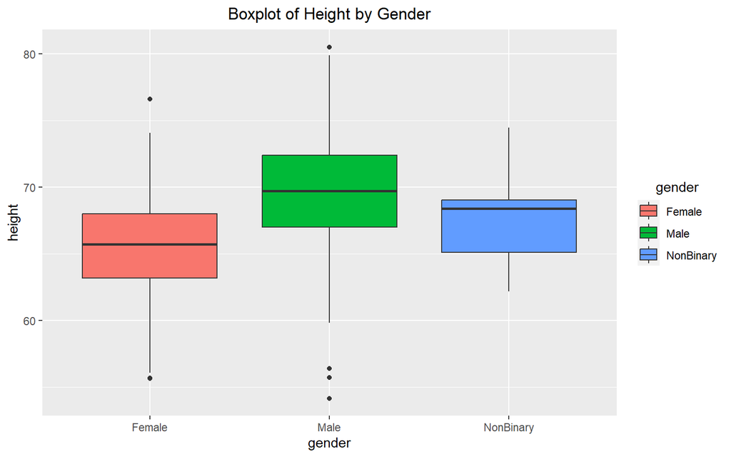

```r
# Load the ggplot library
library(ggplot2)

# Boxplot for height
ggplot(f, aes(x = gender, y = height, fill = gender)) + #Add color
  geom_boxplot() +
  labs(title = "Boxplot of Height by Gender") +
  theme(plot.title = element_text(hjust = 0.5)) + # Center the title
  theme(legend.title.align=0.5) # Center the legend title
```

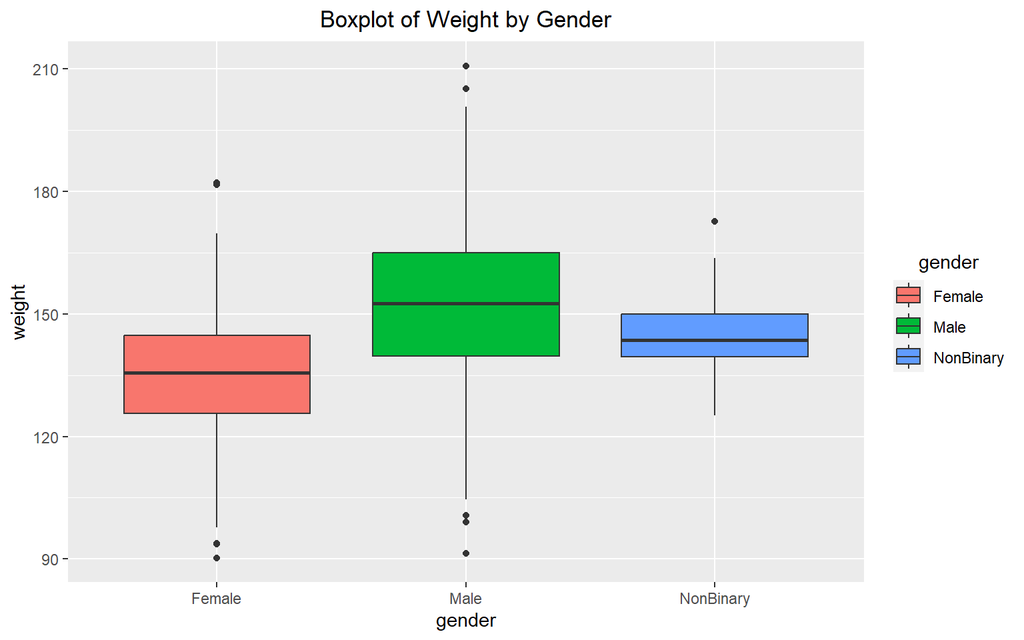

```r
# Boxplot for weight
ggplot(f, aes(x = gender, y = weight, fill = gender)) +
  geom_boxplot() +
  labs(title = "Boxplot of Weight by Gender") +
  theme(plot.title = element_text(hjust = 0.5)) +
  theme(legend.title.align=0.5)
```

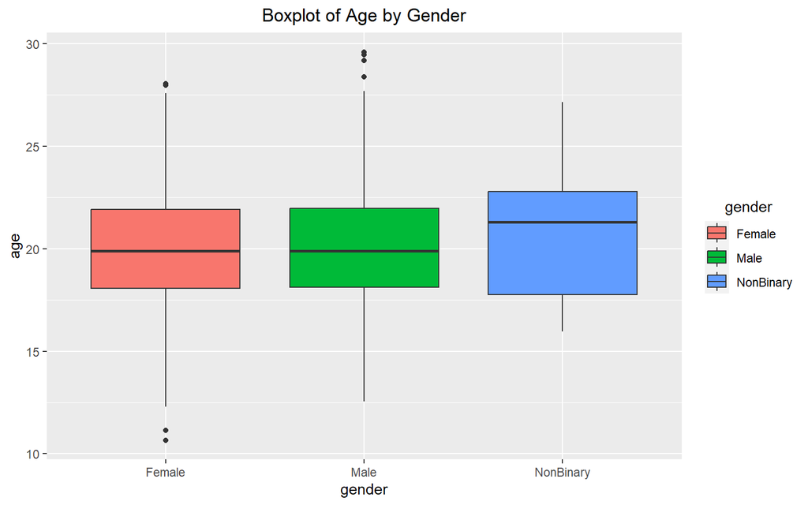

```r
# Boxplot for age
ggplot(f, aes(x = gender, y = age, fill = gender)) +
  geom_boxplot() +
  labs(title = "Boxplot of Age by Gender") +
  theme(plot.title = element_text(hjust = 0.5)) +
  theme(legend.title.align=0.5)
```

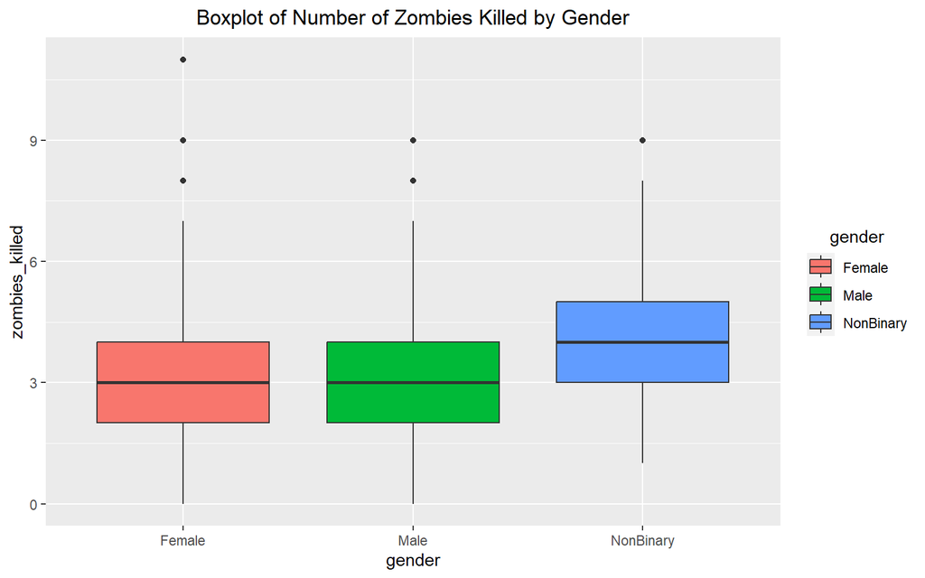

```r
# Boxplot for number of zombies killed
ggplot(f, aes(x = gender, y = zombies_killed, fill = gender)) +
  geom_boxplot() +
  labs(title = "Boxplot of Number of Zombies Killed by Gender") +
  theme(plot.title = element_text(hjust = 0.5)) +
  theme(legend.title.align=0.5)
```

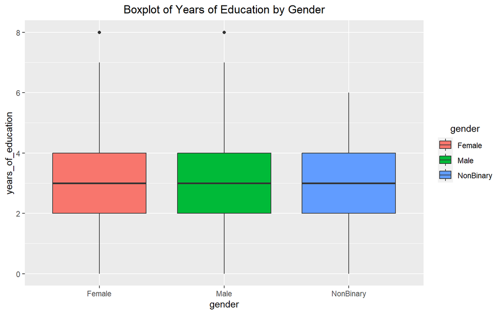

```r
# Boxplot for years of education
ggplot(f, aes(x = gender, y = years_of_education, fill = gender)) +
  geom_boxplot() +
  labs(title = "Boxplot of Years of Education by Gender") +
  theme(plot.title = element_text(hjust = 0.5)) +
  theme(legend.title.align=0.5)
```

## Question #3

**Use {ggplot} to make scatterplots of height and weight in relation to age. Do these variables seem to be related? In what way?**

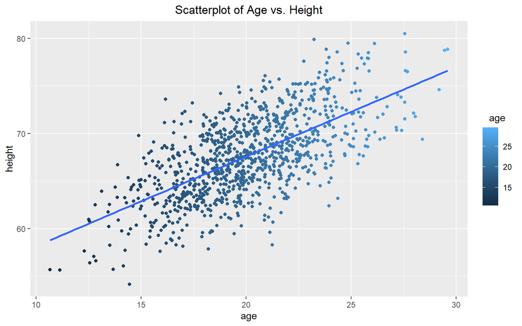

```r
# Scatterplot of age vs. height
ggplot(f, aes(x = age, y = height, color = age)) + #Add color
  geom_point() +
  labs(title = "Scatterplot of Age vs. Height") +
  theme(plot.title = element_text(hjust = 0.5)) + # Center the title
  theme(legend.title = element_text(hjust = 0.5)) + # Center the legend title
  geom_smooth(method = "lm", se = FALSE) # Add slope line
```

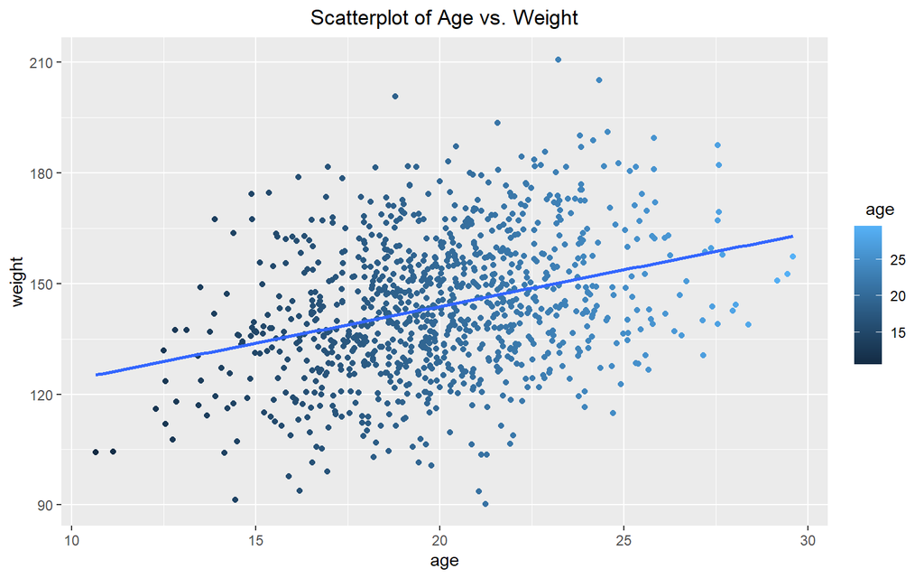

```r
# Scatterplot of age vs. weight
ggplot(f, aes(x = age, y = weight, color = age)) +
  geom_point() +
  labs(title = "Scatterplot of Age vs. Weight")+
  theme(plot.title = element_text(hjust = 0.5)) +
  theme(legend.title = element_text(hjust = 0.5)) +
  geom_smooth(method = "lm", se = FALSE)
```

Yes! These variables appear to be related, as evidenced by the positive correlation in both scatterplots. As age increases, there is a corresponding increase in both height and weight.

## Question #4

**Using histograms and Q-Q plots, check whether the quantitative variables seem to be drawn from a normal distribution. Which seem to be and which do not (hint: not all are drawn from the normal distribution)? For those that are not normal, can you determine from which common distribution they are drawn?**

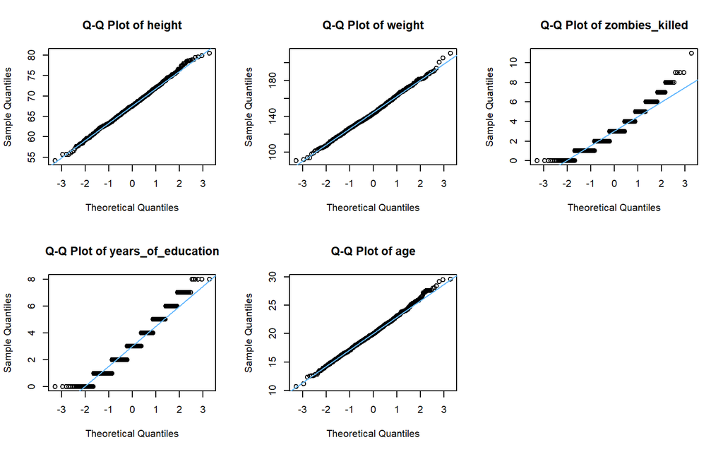

```r
# Input variables to create Q-Q plots
variables_to_plot <- c("height", "weight", "zombies_killed", "years_of_education", "age")

# Create Q-Q plots for each variable with variable names on the x-axis
par(mfrow = c(2, 3))  # Arrange plots in a 2x3 grid

for (variable_name in variables_to_plot) {
  # Create a Q-Q plot for each variable
  qqnorm(f[[variable_name]], main = paste("Q-Q Plot of", variable_name))
  qqline(f[[variable_name]], col = "steelblue1")
}

# Load the data from the CSV file
data <- f

# Input variables to create histograms
variables_to_plot <- c("height", "weight", "age", "zombies_killed", "years_of_education")

par(mfrow = c(2, 3))  # Arrange plots in a 2x3 grid
```

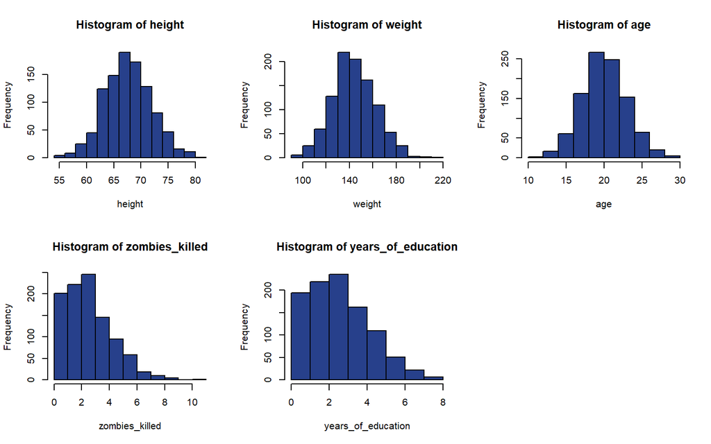

```r
for (variable_name in variables_to_plot) {
  # Create a histogram for each variable
  hist(data[[variable_name]], col = "royalblue4", main = paste("Histogram of", variable_name), xlab = variable_name)

}
```

Quantitative variables that seem to be drawn from a normal distribution include height, weight, and age. Quantitative variables that do not seem to be drawn from a normal distribution include number of zombies killed and years of education. Based on the Q-Q plots and histograms they both skew right and are drawn from a Poisson distribution.

## Question #5

**Now use the sample() function to sample ONE subset of 30 zombie survivors (without replacement) from this population and calculate the mean and sample standard deviation for each variable. Also estimate the standard error for each variable, and construct the 95% confidence interval for each mean. Note that for the variables that are not drawn from the normal distribution, you may need to base your estimate of the CIs on slightly different code than for the normal.**

```r
library(dplyr)
set.seed(100) # Set.seed so you get the same sample size
s <- sample_n(f, 30, replace=FALSE) # Use sample_n() to sample whole rows from a dataframe. Using sample() can only sample from one vector like f$height.
head(s) # Take a peek at the sample
```

```
##    id first_name last_name    gender   height   weight zombies_killed
## 1 714     Edward       Day      Male 66.26057 158.5050              3
## 2 503      Wayne    Harvey      Male 75.56981 180.0224              2
## 3 358 Archimedes    Rogers NonBinary 68.39926 150.4619              2
## 4 624       Eric       Ray      Male 63.42365 131.4085              2
## 5 985       Mark   Roberts      Male 72.37050 169.9783              3
## 6 718     Carlos    Larson      Male 68.50593 139.8103              2
##   years_of_education                                 major      age
## 1                  1                            psychology 17.36132
## 2                  1                             logistics 20.82915
## 3                  1                mechanical engineering 20.92563
## 4                  3                         city planning 17.07766
## 5                  4 integrated water resources management 23.27623
## 6                  3                            psychology 20.36977
```

```r
s <- sample(f$height, size = 30, replace = FALSE)
m <- mean(s)
m
```

```
## [1] 68.34485
```

```r
sd <- sd(s)
sd
```

```
## [1] 4.205049
```

```r
sem <- sd(s)/sqrt(30)
sem
```

```
## [1] 0.7677335
```

```r
lower <- m - qnorm(1 - 0.05/2) * sem  # (1-alpha)/2 each in the upper and lower tails of the distribution
upper <- m + qnorm(1 - 0.05/2) * sem  # (1-alpha)/2 each in the upper and lower tails of the distribution
ci <- c(lower, upper)
ci
```

```
## [1] 66.84012 69.84958
```

```r
s <- sample(f$weight, size = 30, replace = FALSE)
m <- mean(s)
m
```

```
## [1] 143.8904
```

```r
sd <- sd(s)
sd
```

```
## [1] 13.09958
```

```r
sem <- sd(s)/sqrt(30)
sem
```

```
## [1] 2.391645
```

```r
lower <- m - qnorm(1 - 0.05/2) * sem  # (1-alpha)/2 each in the upper and lower tails of the distribution
upper <- m + qnorm(1 - 0.05/2) * sem  # (1-alpha)/2 each in the upper and lower tails of the distribution
ci <- c(lower, upper)
ci
```

```
## [1] 139.2028 148.5779
```

```r
s <- sample(f$age, size = 30, replace = FALSE)
m <- mean(s)
m
```

```
## [1] 20.60803
```

```r
sd <- sd(s)
sd
```

```
## [1] 2.779888
```

```r
sem <- sd(s)/sqrt(30)
sem
```

```
## [1] 0.5075358
```

```r
lower <- m - qnorm(1 - 0.05/2) * sem  # (1-alpha)/2 each in the upper and lower tails of the distribution
upper <- m + qnorm(1 - 0.05/2) * sem  # (1-alpha)/2 each in the upper and lower tails of the distribution
ci <- c(lower, upper)
ci
```

```
## [1] 19.61327 21.60278
```

```r
s <- sample(f$zombies_killed, size = 30, replace = FALSE, prob = NULL)
m <- mean(s)
m
```

```
## [1] 3.633333
```

```r
sd <- sd(s)
sd
```

```
## [1] 1.731719
```

```r
sem <- sd(s)/sqrt(30)
sem
```

```
## [1] 0.3161672
```

```r
set <- NULL  # sets up a dummy variable to hold our 1000 simulations
n <- 30
for (i in 1:1000) {
    set[i] <- mean(sample(s, n, replace = TRUE))
}

quantile(set)
```

```
##       0%      25%      50%      75%     100%
## 2.666667 3.433333 3.633333 3.866667 4.633333
```

```r
quantile(set, c(0.025, 0.975)) # Confidence Intervals by Bootstrapping
```

```
##     2.5%    97.5%
## 3.033333 4.266667
```

```r
poisson.test(length(s), conf.level = 0.95) # Confidence Intervals by a Poisson Test
```

```
##
##  Exact Poisson test
##
## data:  length(s) time base: 1
## number of events = 30, time base = 1, p-value < 2.2e-16
## alternative hypothesis: true event rate is not equal to 1
## 95 percent confidence interval:
##  20.24087 42.82687
## sample estimates:
## event rate
##         30
```

```r
s <- sample(f$years_of_education, size = 30, replace = FALSE)
m <- mean(s)
m
```

```
## [1] 3.333333
```

```r
sd <- sd(s)
sd
```

```
## [1] 2.089932
```

```r
sem <- sd(s)/sqrt(30)
sem
```

```
## [1] 0.3815676
```

```r
set <- NULL  # sets up a dummy variable to hold our 1000 simulations
n <- 30
for (i in 1:1000) {
    set[i] <- mean(sample(s, n, replace = TRUE))
}

quantile(set, c(0.025, 0.975)) # Confidence Intervals by Bootstrapping
```

```
##     2.5%    97.5%
## 2.666667 4.066667
```

```r
poisson.test(length(s), conf.level = 0.95) # Confidence Intervals by a Poisson Test
```

```
##
##  Exact Poisson test
##
## data:  length(s) time base: 1
## number of events = 30, time base = 1, p-value < 2.2e-16
## alternative hypothesis: true event rate is not equal to 1
## 95 percent confidence interval:
##  20.24087 42.82687
## sample estimates:
## event rate
##         30
```

## Question #6

**Now draw 99 more random samples of 30 zombie apocalypse survivors, and calculate the mean for each variable for each of these samples. Together with the first sample you drew, you now have a set of 100 means for each variable (each based on 30 observations), which constitutes a sampling distribution for each variable. What are the means and standard deviations of this distribution of means for each variable? How do the standard deviations of means compare to the standard errors estimated in [5]? What do these sampling distributions look like (a graph might help here)? Are they normally distributed? What about for those variables that you concluded were not originally drawn from a normal distribution?**

```r
x <- NULL # dummy variable to hold each sample
for (i in 1:100) {
    sample_data <- sample(f$height, size = 30, replace = FALSE, prob = NULL)
    x[i] <- mean(sample_data)
}

mean_height <- mean(x)
print (mean_height)
```

```
## [1] 67.59965
```

```r
sd_height <- sd(x)
print (sd_height)
```

```
## [1] 0.8440347
```

```r
par(mfrow = c(2, 3))  # Arrange plots in a 2x3 grid
hist(x, main = "Height (100 samples)", xlab = "Height", col = "royalblue4")

x <- NULL
for (i in 1:100) {
    sample_data <- sample(f$weight, size = 30, replace = FALSE, prob = NULL)
    x[i] <- mean(sample_data)
}

mean_weight <- mean(x)
print (mean_weight)
```

```
## [1] 143.7477
```

```r
sd_weight <- sd(x)
print (sd_weight)
```

```
## [1] 3.663679
```

```r
hist(x, main = "Weight (100 samples)", xlab = "Weight", col = "royalblue4")

x <- NULL
for (i in 1:100) {
    sample_data <- sample(f$age, size = 30, replace = FALSE, prob = NULL)
    x[i] <- mean(sample_data)
}

mean_age <- mean(x)
print (mean_age)
```

```
## [1] 20.12635
```

```r
sd_age <- sd(x)
print (sd_age)
```

```
## [1] 0.5685005
```

```r
hist(x, main = "Age (100 samples)", xlab = "Age", col = "royalblue4")

x <- NULL
for (i in 1:100) {
    sample_data <- sample(f$zombies_killed, size = 30, replace = FALSE, prob = NULL)
    x[i] <- mean(sample_data)
}

mean_zombies_killed <- mean(x)
print (mean_zombies_killed)
```

```
## [1] 3.023
```

```r
sd_zombies_killed <- sd(x)
print (sd_zombies_killed)
```

```
## [1] 0.3188326
```

```r
hist(x, main = "Zombies Killed (100 samples)", xlab = "Zombies Killed", col = "royalblue4")

x <- NULL
for (i in 1:100) {
    sample_data <- sample(f$years_of_education, size = 30, replace = FALSE, prob = NULL)
    x[i] <- mean(sample_data)
}

mean_years_of_education <- mean(x)
print (mean_years_of_education)
```

```
## [1] 2.951667
```

```r
sd_years_of_education <- sd(x)
print (sd_years_of_education)
```

```
## [1] 0.325096
```

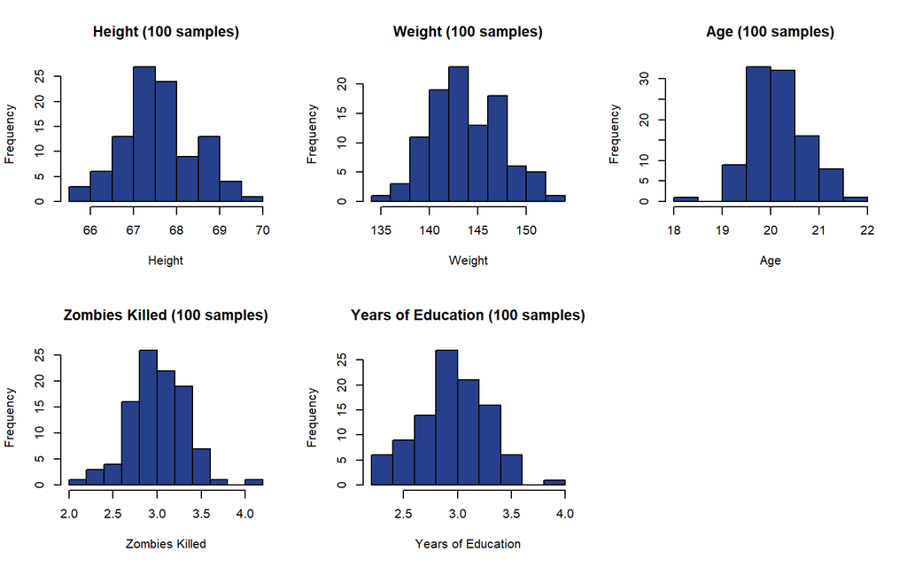

```r
hist(x, main = "Years of Education (100 samples)", xlab = "Years of Education", col = "royalblue4")
```